[figure not shown]

WI-449

Instrument Panel Wiring Harness LH

WIRING SYSTEM

68.Instrument Panel Wiring Harness LH

A: LOCATION

Connector Connecting to

No. Pole Color Area No. Description

i2 20 D-1 R339 Rear wiring harness LH

i5 20 C-2 F/B

i10 40 B-3 Combination meter

i13 4 GR C-3 Trunk lid opener switch

i28 4 GR C-2 OP connector (fog light switch)

i51 2 A-4 Sunload sensor

i55 2 B-4 In-vehicle sensor

i79 6 C-2 Illumination control switch

i84 35 C-2 Body integrated unit

i101 28 D-2 D84 Front door cord LH

i102 20 D-1 R167 Rear wiring harness LH

i122 12 B A-5 MFD

i150 14 B-4 Push button ignition switch

2 B-2 Side tweeter LH (without audio amplifier)

4 B-2 Side tweeter LH (with audio amplifier)

i166 4 B-2

J/C

i167 4 B-2

i171 31 C-2 Body integrated unit

i229 12 C-2 B551

i231 20 C-2 B553

i232 8 B-4

J/C

i233 8 B-4

i234 6 GR C-2 VDC OFF switch

i240 8 B A-4 MFD

: White or natural color

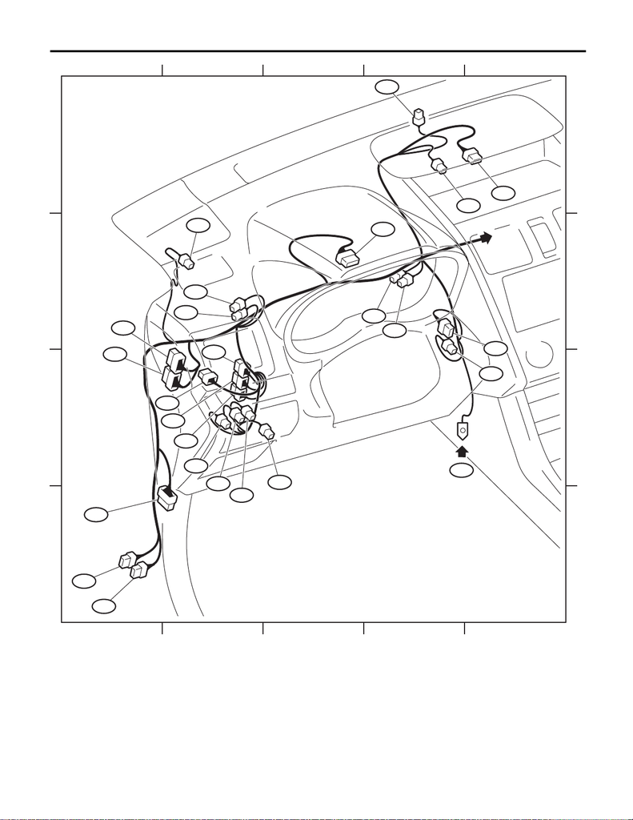

WI-450

Instrument Panel Wiring Harness LH

WIRING SYSTEM

WI-44623

A

B

C

D

A

B

C

D

RH

i84

i171

i5

i102

i2

i234

i101

i79

i28

i13

i158

i231

i230

i166

i167

i229

i232

i233

i150

i55

i240

i122

i51

i10

GB-8